# Python Basics

# Classes

```python
class My_class:

    def __init__(self, x = 10):
        self.x = x

    def func(self):
        print(self.x)


my_class = My_class(50)

my_class.func()
```

```
50
```

**Class inheritance:**

```python
class Parent:

    def __init__(self):
        print("Calling parent constructor")

    def parentMethod(self):
        print('Calling parent method')

    def setAttr(self, attr):
        Parent.parentAttr = attr

    def getAttr(self):
        print("Parent attribute :", Parent.parentAttr)

class Child(Parent): # define child class
    def __init__(self):
        print("Calling child constructor")

    def childMethod(self):
        print('Calling child method')

c = Child()          # instance of child
c.childMethod()      # child calls its method
c.parentMethod()     # calls parent's method
c.setAttr(200)       # again call parent's method
c.getAttr()          # again call parent's method
```

```
Calling child constructor
Calling child method
Calling parent method
Parent attribute : 200
```

# Reading from keyboard

```python
x = input('Enter your name:')
print('Hello, ' + x)
```

```
Enter your name:Jonas
Hello, Jonas
```

# Writing to file

```python
file = open("text.txt","w")

file.write("3, 4, 5,6 ,7 , 8, 9, 0, 4, 3\n")
file.write("a, c, d,f ,g , h, j, k, l, i")

file.close()
```

# Reading from files

```python
# Reading entire file in one go, can fail with large files
file = open("text.txt", "r")
print(file.read())

# Read file line by line
data = []
with open("text.txt", 'r') as f:
    for line in f:
        new_instance = line.strip().split(',')
        data.append(new_instance)

print(data)
```

```
3, 4, 5,6 ,7 , 8, 9, 0, 4, 3
a, c, d,f ,g , h, j, k, l, i
[['3', ' 4', ' 5', '6 ', '7 ', ' 8', ' 9', ' 0', ' 4', ' 3'], ['a', ' c', ' d', 'f ', 'g ', ' h', ' j', ' k', ' l', ' i']]
```

# Exceptions

Exceptions help you respond to errors that can occur in your code

```python
number = input("type an integer: ")

try:
    number = int(number)
except ValueError:
    print("Invalid input")
else:
    print("You did it! " , number)
```

```
type an integer: 5
You did it!  5
```

# Numpy

A library for large multi-dimensional arrays and matrices, along with mathematcal functions to operate the arrays and matrices.

**[reference 1](https://www.tutorialspoint.com/numpy/numpy_introduction.htm)**

**[reference 2](https://docs.scipy.org/doc/numpy-1.15.0/user/quickstart.html#quickstart-shape-manipulation)**

## Operations using NumPy

Using NumPy, a developer can perform the following operations −

- Mathematical and logical operations on arrays.
- Fourier transforms and routines for shape manipulation.
- Operations related to linear algebra. NumPy has in-built functions for linear algebra and random number generation.

### Environment

```python
# Install
!pip install numpy

# Imprting
import numpy as np
```

### Ndarray Object

NumPy’s array class is called ndarray. This object is not the same as the standard array.array class in python. The ndarray object handles multi-dimensional arrays, and offers more functionality. A basic numpy array does not support **multiple data types**, for multiple arrays with multiple data types (**[structured arrays](https://docs.scipy.org/doc/numpy-1.10.4/user/basics.rec.html)**) can be used.

```python
# Create array
a = np.array([1,2,3])

# More than one dimension
a = np.array([[1, 2], [3, 4]])

# Define minimum dimensions
a = np.array([1, 2, 3, 4, 5], ndmin = 2)

# Define data type
a = np.array([1, 2, 3], dtype = complex)

print(a)
```

```
[1.+0.j 2.+0.j 3.+0.j]
```

### Array Creation Routines

```python
# zeroes fills an array with zeroes
a = np.zeros((4,5))

# ones fills an array with ones
a = np.ones((2,4,6))

# empty fills an array with random content
a = np.empty((2,4))

# random fills an array with random numbers
a = np.random.random((2,3))* 10

# Arange fills array with a sequence
a = np.arange(4, 11)

# Steps in sequence can be defined with a third parameter
a = np.arange(10, 25, 5)
a = np.arange(0, 10, 0.1)

# linspace is similar to arange. But it uses unlike arange the
# third variable to define the number of floating point variables
# in the range

a = np.linspace(0, 3, 100)
print(a)
```

```
[0.         0.03030303 0.06060606 0.09090909 0.12121212 0.15151515
 0.18181818 0.21212121 0.24242424 0.27272727 0.3030303  0.33333333
 0.36363636 0.39393939 0.42424242 0.45454545 0.48484848 0.51515152
 0.54545455 0.57575758 0.60606061 0.63636364 0.66666667 0.6969697
 0.72727273 0.75757576 0.78787879 0.81818182 0.84848485 0.87878788
 0.90909091 0.93939394 0.96969697 1.         1.03030303 1.06060606
 1.09090909 1.12121212 1.15151515 1.18181818 1.21212121 1.24242424
 1.27272727 1.3030303  1.33333333 1.36363636 1.39393939 1.42424242
 1.45454545 1.48484848 1.51515152 1.54545455 1.57575758 1.60606061
 1.63636364 1.66666667 1.6969697  1.72727273 1.75757576 1.78787879
 1.81818182 1.84848485 1.87878788 1.90909091 1.93939394 1.96969697
 2.         2.03030303 2.06060606 2.09090909 2.12121212 2.15151515
 2.18181818 2.21212121 2.24242424 2.27272727 2.3030303  2.33333333
 2.36363636 2.39393939 2.42424242 2.45454545 2.48484848 2.51515152
 2.54545455 2.57575758 2.60606061 2.63636364 2.66666667 2.6969697
 2.72727273 2.75757576 2.78787879 2.81818182 2.84848485 2.87878788
 2.90909091 2.93939394 2.96969697 3.        ]
```

Here are some important attributes of the **ndarray** object:

```python
a = np.arange(20).reshape(4, 5)
print(a)

# Shape returns the dimensions of an array. For a 2 dimensional array
# it would return a tuple with (n rows, n columns)
print("shape: ", a.shape)

# ndim returns the number of dimensions in an array
print("ndim: ", a.ndim)

# dtype returns the data type of the elements of an array
print("dtype: ", a.dtype.name)

# The number of bytes for each element in an array
print("itemsize: ", a.itemsize)

# The total number of elements in an array
print("size: ", a.size)
```

```
[[ 0  1  2  3  4]
 [ 5  6  7  8  9]
 [10 11 12 13 14]
 [15 16 17 18 19]]
shape:  (4, 5)
ndim:  2
dtype:  int32
itemsize:  4
size:  20
```

### Basic Operations

Arithmetic operators on arrays apply elementwise. A new array is created and filled with the result.

```python
a = np.array( [20,30,40,50] )
b = np.array( [0, 1, 2, 3] )

# Addition
c = a+b

# Exponentation
c = b**2

# Multiplication
c = b*5

# Sinus
c = 10*np.sin(a)

# Less than
c = a<35
print(c)

# Matrix product
A = np.array( [[1,1],
               [0,1]] )

B = np.array( [[2,0],
               [3,4]] )
C = A @ B
# or
C = A.dot(B)

print(C)
```

```
[ True  True False False]
[[5 4]
 [3 4]]
```

Universal functions also operate elementwise in numpy.

```python
a = np.arange(5)
print(a)
print(np.exp(a))
print(np.sqrt(a))
print(np.cos(a))
```

```
[0 1 2 3 4]
[ 1.          2.71828183  7.3890561  20.08553692 54.59815003]
[0.         1.         1.41421356 1.73205081 2.        ]
[ 1.          0.54030231 -0.41614684 -0.9899925  -0.65364362]
```

### Slicing and iterating

One-dimensional arrays can be indexed, sliced and iterated over, much like lists(above) and other Python sequences.

```python
print(a[2:4])
print(a[ : :-1])
```

```
[2 3]
[4 3 2 1 0]
```

For multidimensional arrays, each dimension needs to be separated by a comma.

```python
b = np.array([[ 0,  1,  2,  3],
               [10, 11, 12, 13],
               [20, 21, 22, 23],
               [30, 31, 32, 33],
               [40, 41, 42, 43]])

# Indexing 3rd row and 4th column (starts at 0)
print(b[2,3])

# each row in the second column of b
print(b[0:, 1])

# The first second and third elements in the first to the third
# column of b
print(b[0:3, 1:3])
print(b[3:, 2:])
```

```
23
[ 1 11 21 31 41]
[[ 1  2]
 [11 12]
 [21 22]]
[[32 33]
 [42 43]]
```

Iterating over multidimensional arrays is done with respect to the first axis:

```python
for row in b:
    print(row)

# .flat can be used to flatten a multidimensional array into a
# one-dimensional array
for element in b.flat:
    print(element)
```

```
[0 1 2 3]
[10 11 12 13]
[20 21 22 23]
[30 31 32 33]
[40 41 42 43]
0
1
2
3
10
11
12
13
20
21
22
23
30
31
32
33
40
41
42
43
```

## Shape manipulation

```python
a = np.floor(np.random.random((3,4))*10)
print(a)
print(a.shape)

# Flattens the array
a = a.ravel()
print(a)

# Reshapes the array
b = a.reshape(3, 4)
print(b)

# Transpose the array
b = a.T
print(b)
```

```
[[5. 5. 9. 1.]
 [7. 2. 8. 9.]
 [6. 5. 4. 2.]]
(3, 4)
[5. 5. 9. 1. 7. 2. 8. 9. 6. 5. 4. 2.]
[[5. 5. 9. 1.]
 [7. 2. 8. 9.]
 [6. 5. 4. 2.]]
[5. 5. 9. 1. 7. 2. 8. 9. 6. 5. 4. 2.]
```

# Matplotlib

Data visualization library for python. Great for making visual representations of data.

matplotlib.pyplot is a collection of command style functions that make matplotlib work like MATLAB. Each pyplot function makes some change to a figure: e.g., creates a figure, creates a plotting area in a figure, plots some lines in a plotting area, decorates the plot with labels, etc.

**[Reference](https://matplotlib.org/tutorials/introductory/pyplot.html)**

```python
# Installation and importing
!pip install matplotlib
import matplotlib.pyplot as plt
%matplotlib inline
```

## Basic plot

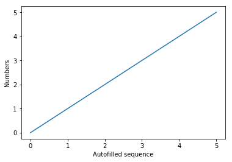

```python
y = np.arange(6)

# Plot array
plt.plot(y)
# Set labels
plt.ylabel("Numbers") # y label
plt.xlabel("Autofilled sequence") # x label
plt.show()
```

As you can see, if only a single array is passed to plot(), matplotlib will automatically generate the x-values.

The x-values can be defined by passing a second array.

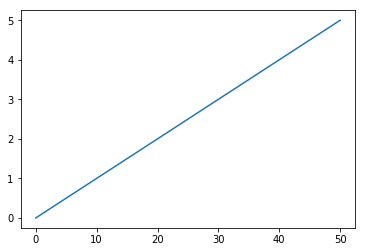

```python
x = [0, 10, 20, 30, 40, 50]
plt.plot(x,y)
plt.show()
```

### Labels and ticks

How to label different parts of the plot, add text, and change precision of axes:

```
[ 0.   0.5  1.   1.5  2.   2.5  3.   3.5  4.   4.5  5.   5.5  6.   6.5
  7.   7.5  8.   8.5  9.   9.5 10.  10.5]
```

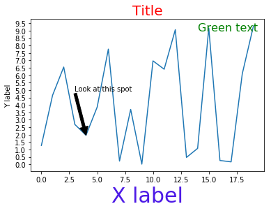

```python
a = np.random.random(20)*10
ticks = np.arange(0, 11, 0.5)
print(ticks)

plt.title('Title', color='red', fontsize=20)
plt.xlabel('X label', color=(0.3, 0.1, 0.9), fontsize=30)
plt.ylabel('Y label')
plt.yticks(ticks) # precision of y axis

# Add some text
plt.text(14, 9, 'Green text', color='green', fontsize=16)

# Create annotation
plt.annotate('Look at this spot', xy=(4, a[4]), xytext=(3, a[4]+3),
             arrowprops=dict(facecolor='black'),)
plt.plot(a)
plt.show()
```